# Data Exploration

Kenneth L Osborne

August 25, 2018

```r
suppressPackageStartupMessages(library(magrittr))
suppressPackageStartupMessages(library(tidyverse))
suppressPackageStartupMessages(library(lubridate))
```

# Data Exploration

Data Exploration

Challenge 1: Data Exploration To complete this challenge:

1. Download the Adventure Works data files - see previous unit.
2. Clean the data by replacing any missing values and removing duplicate rows. In this dataset, each customer is identified by a unique customer ID. The most recent version of a duplicated record should be retained.
3. Explore the data by calculating summary and descriptive statistics for the features in the dataset, calculating correlations between features, and creating data visualizations to determine apparent relationships in the data.
4. Based on your analysis of the customer data after removing all duplicate customer records, answer the questions below.

## Initial Data Exploration

Loading the csv files into dataframes in R goes as follows.

```r
customerInfo <- read.csv("AdvWorksCusts.csv", stringsAsFactors = FALSE)
bikeBuyer    <- read.csv("AW_BikeBuyer.csv")
spend        <- read.csv("AW_AveMonthSpend.csv")
```

Looking at the structure of each data frame:

```r
customerInfo %>% str()
```

```
## 'data.frame':    16519 obs. of  23 variables:
##  $ CustomerID          : int  11000 11001 11002 11003 11004 11005 11006 11007 11008 11009 ...
##  $ Title               : chr  "" "" "" "" ...
##  $ FirstName           : chr  "Jon" "Eugene" "Ruben" "Christy" ...
##  $ MiddleName          : chr  "V" "L" "" "" ...
##  $ LastName            : chr  "Yang" "Huang" "Torres" "Zhu" ...
##  $ Suffix              : chr  "" "" "" "" ...
##  $ AddressLine1        : chr  "3761 N. 14th St" "2243 W St." "5844 Linden Land" "1825 Village Pl." ...
##  $ AddressLine2        : chr  "" "" "" "" ...
##  $ City                : chr  "Rockhampton" "Seaford" "Hobart" "North Ryde" ...
##  $ StateProvinceName   : chr  "Queensland" "Victoria" "Tasmania" "New South Wales" ...
##  $ CountryRegionName   : chr  "Australia" "Australia" "Australia" "Australia" ...
##  $ PostalCode          : chr  "4700" "3198" "7001" "2113" ...
##  $ PhoneNumber         : chr  "1 (11) 500 555-0162" "1 (11) 500 555-0110" "1 (11) 500 555-0184" "1 (11) 500 555-0162" ...
##  $ BirthDate           : chr  "1966-04-08" "1965-05-14" "1965-08-12" "1968-02-15" ...
##  $ Education           : chr  "Bachelors " "Bachelors " "Bachelors " "Bachelors " ...
##  $ Occupation          : chr  "Professional" "Professional" "Professional" "Professional" ...
##  $ Gender              : chr  "M" "M" "M" "F" ...
##  $ MaritalStatus       : chr  "M" "S" "M" "S" ...
##  $ HomeOwnerFlag       : int  1 0 1 0 1 1 1 1 1 0 ...
##  $ NumberCarsOwned     : int  0 1 1 1 4 1 1 2 3 1 ...
##  $ NumberChildrenAtHome: int  0 3 3 0 5 0 0 3 4 0 ...
##  $ TotalChildren       : int  2 3 3 0 5 0 0 3 4 0 ...
##  $ YearlyIncome        : int  137947 101141 91945 86688 92771 103199 84756 109759 88005 106399 ...
```

```r
bikeBuyer %>% str()
```

```
## 'data.frame':    16519 obs. of  2 variables:
##  $ CustomerID: int  11000 11001 11002 11003 11004 11005 11006 11007 11008 11009 ...
##  $ BikeBuyer : int  0 1 0 0 1 1 1 1 1 0 ...
```

```r
spend %>% str()
```

```
## 'data.frame':    16519 obs. of  2 variables:
##  $ CustomerID   : int  11000 11001 11002 11003 11004 11005 11006 11007 11008 11009 ...
##  $ AveMonthSpend: int  89 117 123 50 95 78 54 130 85 74 ...
```

`customerInfo` has 23 different variables, most of which are personal information for different customers. `bikeBuyer` has a customerID and a logical indicator that determines whether or not the customer bought a bike. `spend` has the same customerID as the other two data frames, but also indicates the average amount spent per month in the indicated time.

Each dataframe has 16519 observations.

## Cleaning Data

We’ll check for `NA` values and duplicate customerIDs.

```r
countNA <- function(x) {is.na(x) %>% sum()}

apply( customerInfo,2,countNA )
```

```
##           CustomerID                Title            FirstName
##                    0                    0                    0
##           MiddleName             LastName               Suffix
##                    0                    0                    0
##         AddressLine1         AddressLine2                 City
##                    0                    0                    0
##    StateProvinceName    CountryRegionName           PostalCode
##                    0                    0                    0
##          PhoneNumber            BirthDate            Education
##                    0                    0                    0
##           Occupation               Gender        MaritalStatus
##                    0                    0                    0
##        HomeOwnerFlag      NumberCarsOwned NumberChildrenAtHome
##                    0                    0                    0
##        TotalChildren         YearlyIncome
##                    0                    0
```

```r
apply( bikeBuyer,   2,countNA )
```

```
## CustomerID  BikeBuyer
##          0          0
```

```r
apply( spend,       2,countNA )
```

```
##    CustomerID AveMonthSpend
##             0             0
```

None of the dataframes have `NA` values. Although not present in this data, some data sets may have NA values that show up as other values.

Here, customerInfo shows that many customers left several fields intentionally blank (e.g. Title, MiddleName, Suffix, AddressLine2). These are different than NA values because a “” value indicates the customer did not enter any value, whereas an `NA` indicates an unknown value.

Moving on, we work to remove duplicate entries.

```r
customerInfo %>% nrow()
```

```
## [1] 16519
```

```r
customerInfo %<>% .[!duplicated(.),]
bikeBuyer %<>% .[!duplicated(.),]
spend %<>% .[!duplicated(.),]

cat(
  customerInfo %>% nrow(),
  bikeBuyer %>% nrow(),
  spend %>% nrow()
)
```

```
## 16421 16408 16421
```

Here we’ve removed all customers with exactly repeated data, but we see that `bikeBuyer` ended up with fewer rows than the other dataframes. The suspicion is that although we’ve eliminated “total duplications”, there are still several repeated `CustomerIDs` with slightly varying entries.

```r
cat(
  customerInfo$CustomerID %>% unique() %>% length(),
  bikeBuyer$CustomerID %>% unique() %>% length(),
  spend$CustomerID %>% unique() %>% length()
)
```

```
## 16404 16404 16404
```

Indeed, we see that all our data frames have some duplicated `CustomerID` values. Normally we would look for a criterion that would help us decide which values to keep, but thankfully we were provided with such a criterion at the beginning of this challenge–

2. Clean the data by replacing any missing values and removing duplicate rows. In this dataset, each customer is identified by a unique customer ID. The most recent version of a duplicated record should be retained.

Inspecting the data, we see that `CustomerID` mostly increases by one from entry to entry:

```r
bikeBuyer %>% head %>% as.tibble
```

```
## # A tibble: 6 x 2
##   CustomerID BikeBuyer
## *      <int>     <int>
## 1      11000         0
## 2      11001         1
## 3      11002         0
## 4      11003         0
## 5      11004         1
## 6      11005         1
```

This leads us to believe that earlier entries have lower row numbers. Resultingly, we can keep the highest row number from each distinct `CustomerID` to only retain the most recent version of a record. If this works, then we should see that each dataframe has 16404 rows, equal to the number of unique `CustomerID` values.

```r
keepOldest <- function(df){

  df %<>% .[nrow(.)[1]:1,] #reverse the order of rows in the df
  df %<>% distinct( #keep the first CustomerID, drop the rest
    CustomerID , .keep_all = TRUE)
  df %<>% .[nrow(.)[1]:1,] #change the df order back to normal
  df

}

customerInfo %<>% keepOldest()
bikeBuyer %<>% keepOldest()
spend %<>% keepOldest()

cat(
  nrow(customerInfo),
  nrow(bikeBuyer),
  nrow(spend)
)
```

```
## 16404 16404 16404
```

Since everything seems to be working out, we’ll combine all the data into one big dataframe.

```r
customerData <- left_join(customerInfo, bikeBuyer, by = "CustomerID") %>%
  left_join(., spend, by = "CustomerID")
```

## Investigate Basic Trends

The tasks assigned in this challenge are to investigate some basic trends within the data.

### Spending Summary Statistics

The first few questions are about summary statistics for the `AveMonthSpend` variable. We’ll plot a histogram of this variable.

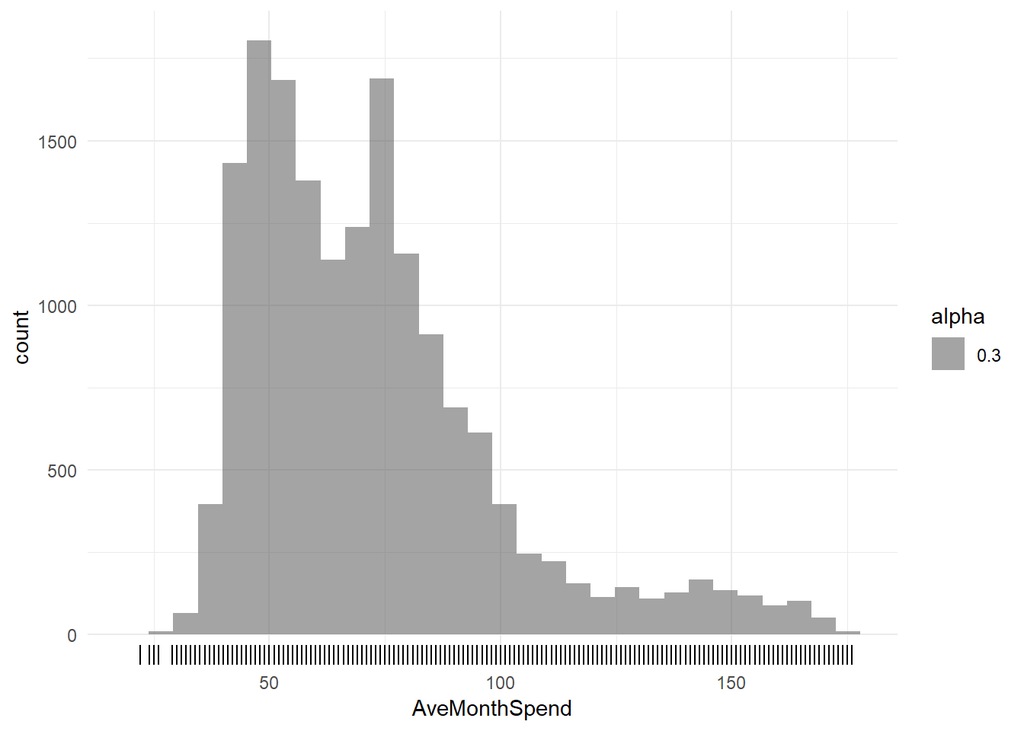

```r
ggplot(customerData) +
  geom_histogram(aes(x = AveMonthSpend, alpha = .3)) +
  geom_rug(aes(x = AveMonthSpend)) +
  theme_minimal()
```

We see that the distribution is skewed right. We’ll get a bit more quantitative information with a few summary statistics.

```r
cat(
  summary(customerData$AveMonthSpend),
  sd(customerData$AveMonthSpend)
)
```

```
## 22 52 68 72.391 84 176 27.26992
```

With this information we can answer the first five questions.

### Bike Buyers

The next question is about the distribution of bike buyers.

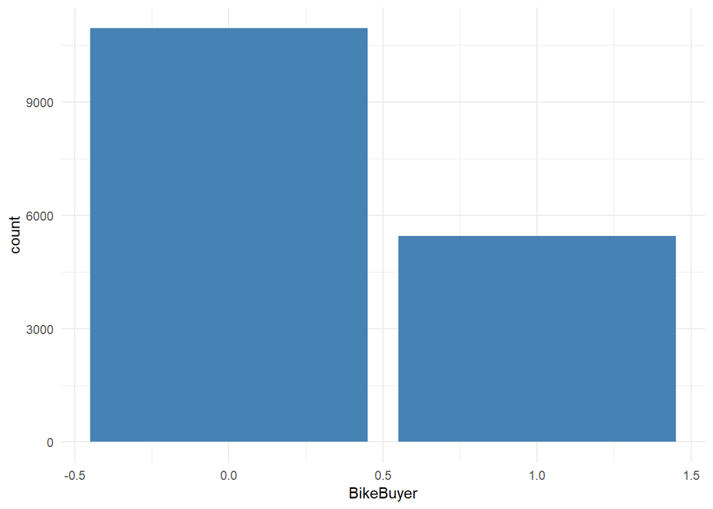

```r
ggplot(customerData, aes(x = BikeBuyer)) +
  geom_bar(fill = "steelblue") +
  theme_minimal()
```

6. The distribution of the values in the BikeBuyer column indicates: Fewer customers have bought bikes than have not bought bikes.

### YearlyIncome and Occupation

The next question asks for the rank ordering of Occupation by Median Yearly Income

We can begin by visualizing the data with a violin plot.

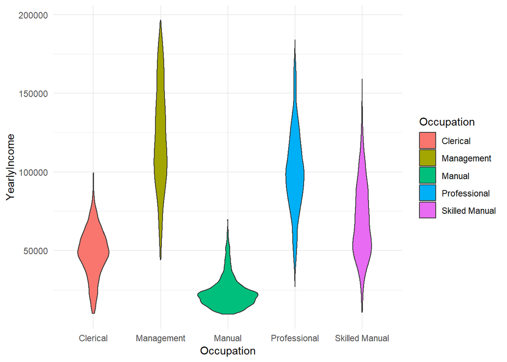

```r
ggplot(customerData, aes(x=Occupation, y=YearlyIncome, fill=Occupation)) +
  geom_violin() +
  theme_minimal()
```

Already we get some sense of the rank ordering, but we’ll also do a quantitative analysis.

```r
customerData %>%
  group_by(Occupation) %>%
  summarize(medianIncome = median(YearlyIncome), n = n()) %>%
  arrange(medianIncome)
```

```
## # A tibble: 5 x 3
##   Occupation     medianIncome     n
##   <chr>                 <dbl> <int>
## 1 Manual               21722   2129
## 2 Clerical             49481   2597
## 3 Skilled Manual       66472.  4038
## 4 Professional         99058   4922
## 5 Management          118781   2718
```

7. Select the correct order (from lowest to highest) that ranks the median YearlyIncome by Occupation:

Manual, Clerical, Skilled Manual, Professional, Management

### Monthly Spending by Age and Sex

The next question asks about monthly spending habits by age and sex, as of 1998 January 01. To determine age, we need to use the birth date and the date in question.

```r
customerData %<>% mutate( Age = interval(BirthDate, "1998-01-01")/dyears() )
customerData %>% select(CustomerID, Gender, BirthDate, Age) %>% head()
```

```
##   CustomerID Gender  BirthDate      Age
## 1      11000      M 1966-04-08 31.75616
## 2      11001      M 1965-05-14 32.65753
## 3      11002      M 1965-08-12 32.41096
## 4      11003      F 1968-02-15 29.89863
## 5      11004      F 1968-08-08 29.41918
## 6      11005      M 1965-08-05 32.43014
```

The question asks about Males and Females from 3 different groups:

1. Under 25
2. 25 - 45
3. Over 55

We can turn our age variable into several categorical variables to compare more easily.

```r
customerData %<>% mutate( AgeCategory = cut(Age, c(0,25,45,55,max(Age)+1)) )
levels(customerData$AgeCategory)
```

```
## [1] "(0,25]"    "(25,45]"   "(45,55]"   "(55,88.4]"
```

With these new categories, we can plot the distributions of male and female spending by age category.

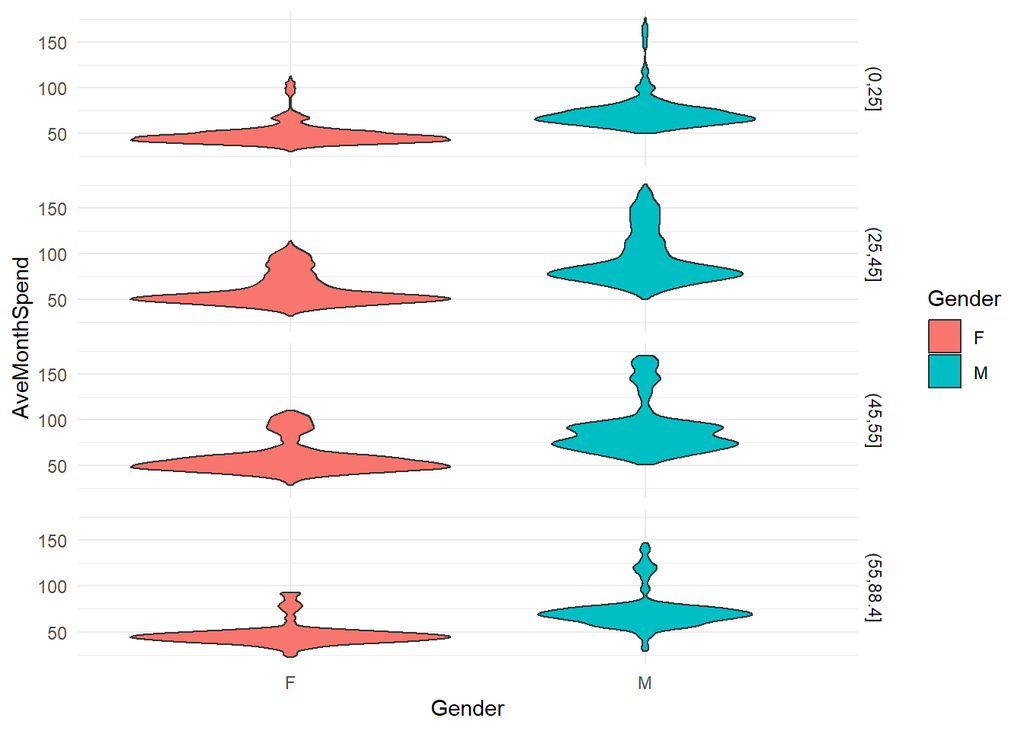

```r
ggplot(customerData, aes(x=Gender, y=AveMonthSpend, fill=Gender)) +
  geom_violin() +
  facet_grid(rows = vars(AgeCategory)) +
  theme_minimal()
```

This gives us some idea that males spend more at the bike store than females across all age categories. Comparing just males, we can break down by age category to see who spends the most.

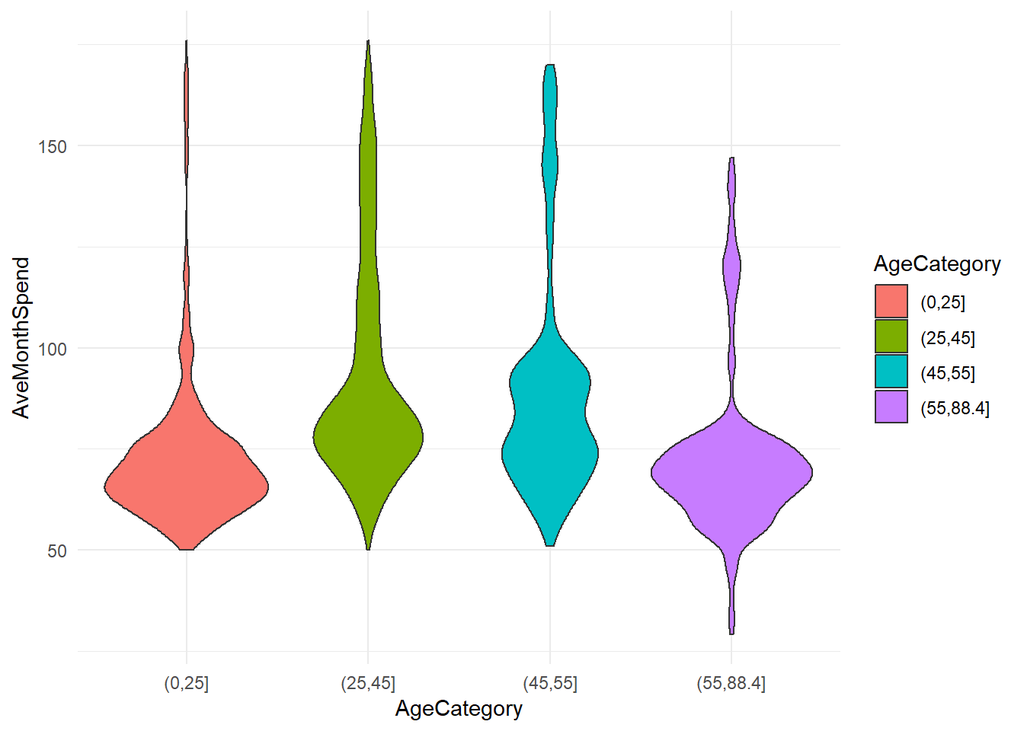

```r
ggplot(
  customerData %>% filter(Gender == "M"),
  aes(x=AgeCategory, y=AveMonthSpend, fill=AgeCategory)
) +
  geom_violin() +
  theme_minimal()
```

It looks like Males Aged 25-55 are the highest spenders, but a quantitative analysis will be insightful.

```r
customerData %>%
  group_by(Gender, AgeCategory) %>%
  summarize(
    meanSpend = mean(AveMonthSpend),
    medianSpend = median(AveMonthSpend),
    n=n()) %>%
  arrange(desc(meanSpend))
```

```
## # A tibble: 8 x 5
## # Groups:   Gender [2]
##   Gender AgeCategory meanSpend medianSpend     n
##   <chr>  <fct>           <dbl>       <dbl> <int>
## 1 M      (25,45]          93.4          83  5068
## 2 M      (45,55]          89.4          83  1223
## 3 M      (0,25]           73.0          69  1475
## 4 M      (55,88.4]        72.5          69   524
## 5 F      (25,45]          59.8          54  4913
## 6 F      (45,55]          57.9          53  1207
## 7 F      (0,25]           48.4          46  1456
## 8 F      (55,88.4]        46.8          45   538
```

We now have enough information to answer the question.

8. Based on their age at the time when the data was collected (1st January 1998), which group of customers accounts for the highest AveMonthSpend values?

### Average Monthly Spending Habits

This question asks a variety of questions about the variable `AveMonthSpend`, and it’s interaction with other variables.

#### Married vs Single

How does marital status interact with spending habits

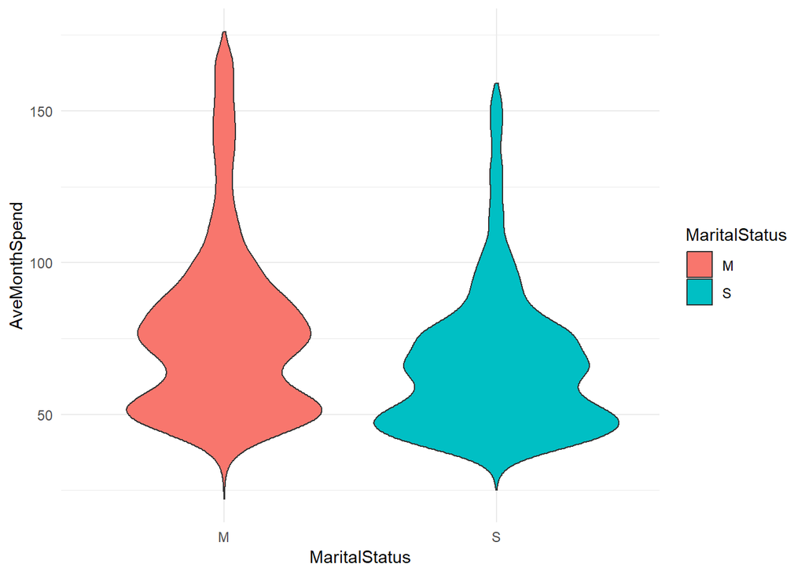

```r
ggplot(customerData, aes(x=MaritalStatus, y=AveMonthSpend, fill = MaritalStatus)) +
  geom_violin() + theme_minimal()
```

It looks like Single Customers are spending less than Married Customers.

```r
customerData %>%
  group_by(MaritalStatus) %>%
  summarize(
    meanSpend = mean(AveMonthSpend),
    medianSpend = median(AveMonthSpend),
    n = n()
  )
```

```
## # A tibble: 2 x 4
##   MaritalStatus meanSpend medianSpend     n
##   <chr>             <dbl>       <dbl> <int>
## 1 M                  77.9          74  8852
## 2 S                  66.0          62  7552
```

Married customers have a higher median `AvgMonthSpend` than single customers.

#### Car Count

Checking in on how car count weighs in. First we’ll categorize car owners into 3 groups.

```r
customerData %<>% mutate( CarCategory = cut(
  NumberCarsOwned,
  c(0,1,3,max(NumberCarsOwned)+1),
  right = FALSE
  )
)
customerData$CarCategory %>% levels()
```

```
## [1] "[0,1)" "[1,3)" "[3,5)"
```

We now use these categories to compare spending habits.

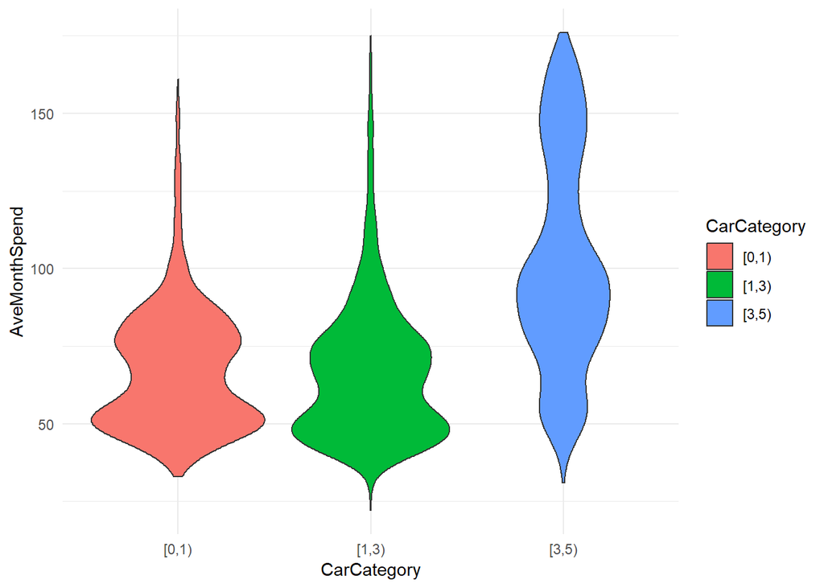

```r
ggplot(customerData, aes(CarCategory, AveMonthSpend, fill = CarCategory)) +
  geom_violin() + theme_minimal()
```

It’s clear that people with 3 or more cars spend the most, on average. A quantitative description follows.

```r
customerData %>%
  group_by(CarCategory) %>%
  summarize(
    meanSpend = mean(AveMonthSpend),
    medianSpend = median(AveMonthSpend),
    n = n()
  )
```

```
## # A tibble: 3 x 4
##   CarCategory meanSpend medianSpend     n
##   <fct>           <dbl>       <dbl> <int>
## 1 [0,1)            67.5          65  3782
## 2 [1,3)            66.8          64 10066
## 3 [3,5)           102.           96  2556
```

Customers with no car have a LOWER median AvgMonthSpend than customers with three or more cars.

#### Gender

Gender differences are as follows

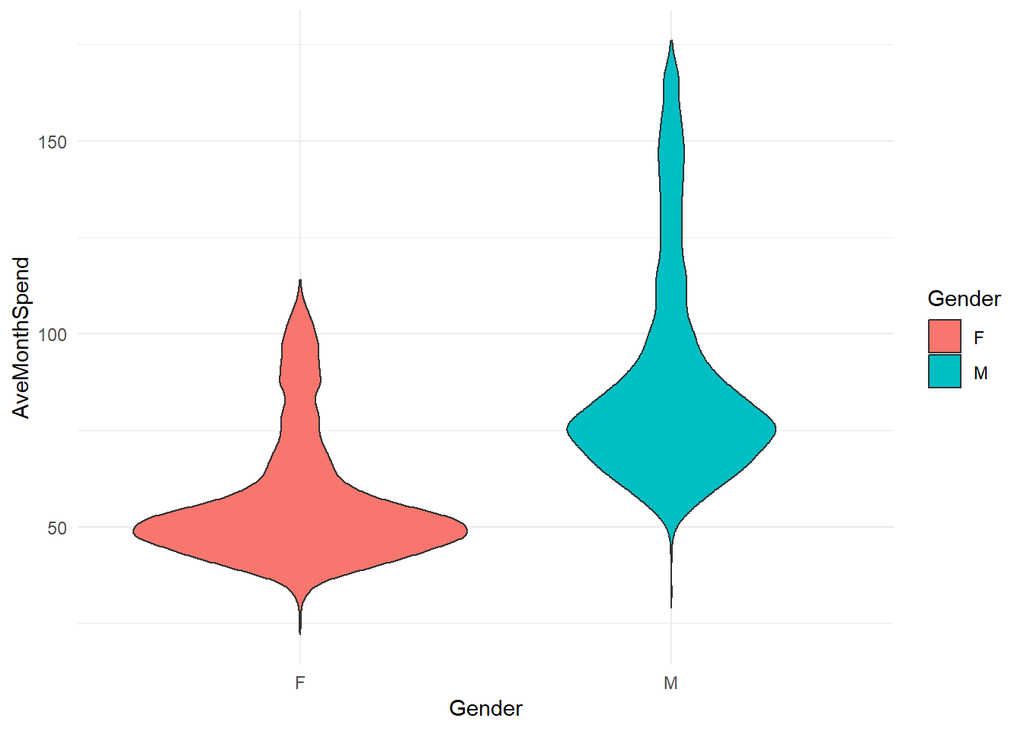

```r
ggplot(customerData, aes(Gender, AveMonthSpend, fill = Gender)) +
  geom_violin() + theme_minimal()
```

Quantitatively speaking

```r
customerData %>%
  group_by(Gender) %>%
  summarize(
    meanSpend = mean(AveMonthSpend),
    medianSpend = median(AveMonthSpend),
    minSpend = min(AveMonthSpend),
    maxSpend = max(AveMonthSpend),
    n = n()
  ) %>%
  mutate(rangeSpend = maxSpend - minSpend)
```

```
## # A tibble: 2 x 7
##   Gender meanSpend medianSpend minSpend maxSpend     n rangeSpend
##   <chr>      <dbl>       <dbl>    <dbl>    <dbl> <int>      <dbl>
## 1 F           56.6          52       22      114  8114         92
## 2 M           87.8          79       29      176  8290        147
```

Male customers have a higher median AvgMonthSpend than female customers. Female customers DO NOT have a wider range of AvgMonthSpend values than male customers.

#### Children at Home

The number of children at home can easily be turned into a logical variable

```r
customerData %<>% mutate( ChildrenHome = as.logical(NumberChildrenAtHome))
```

With this we can see differences between the groups.

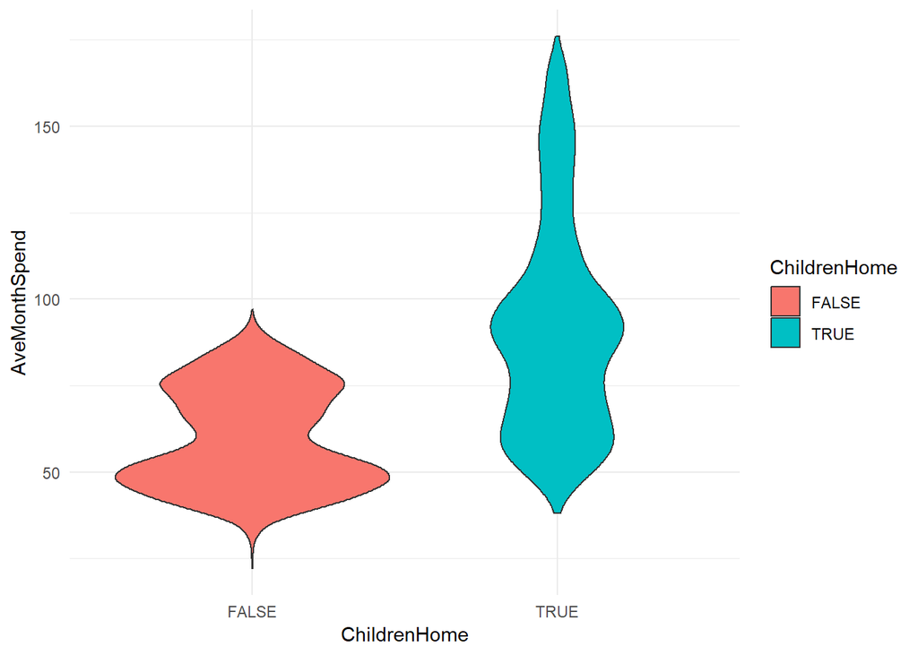

```r
ggplot(customerData, aes(ChildrenHome, AveMonthSpend, fill = ChildrenHome)) +
  geom_violin() + theme_minimal()
```

```r
customerData %>%
  group_by(ChildrenHome) %>%
  summarize(
    meanSpend = mean(AveMonthSpend),
    medianSpend = median(AveMonthSpend),
    n = n()
  )
```

```
## # A tibble: 2 x 4
##   ChildrenHome meanSpend medianSpend     n
##   <lgl>            <dbl>       <dbl> <int>
## 1 FALSE             59.8          57  9924
## 2 TRUE              91.7          88  6480
```

Customers with no children at home have a lower median AvgMonthSpend values than customers with one or more children at home.

### Bike Buyers

This section looks at variables correlating to customers buying a bike.

#### Yearly Income

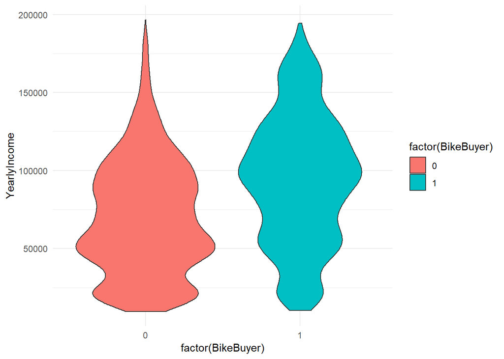

```r
ggplot(customerData, aes(factor(BikeBuyer), YearlyIncome, fill = factor(BikeBuyer))) +
  geom_violin() + theme_minimal()
```

```r
customerData %>%
  group_by(BikeBuyer) %>%
  summarize(
    meanIncome = mean(YearlyIncome),
    medianIncome = median(YearlyIncome),
    n = n()
  )
```

```
## # A tibble: 2 x 4
##   BikeBuyer meanIncome medianIncome     n
##       <int>      <dbl>        <int> <int>
## 1         0     70094.        65957 10949
## 2         1     94258.        96084  5455
```

The median YearlyIncome is higher for customers who bought a bike than for customers who didn’t.

#### Cars Owned

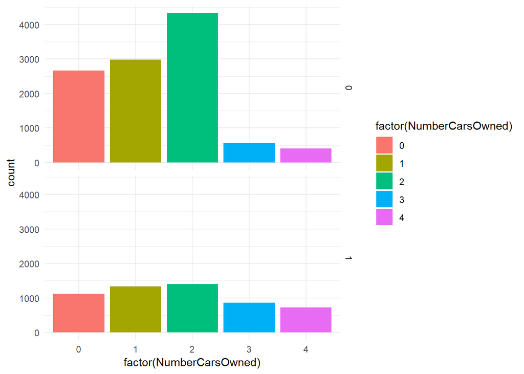

```r
ggplot(customerData, aes(factor(NumberCarsOwned), fill = factor(NumberCarsOwned))) +
  geom_bar() +
  facet_grid(vars(factor(BikeBuyer))) +
  theme_minimal()
```

```r
customerData %>%
  group_by(BikeBuyer) %>%
  summarize(
    meanCars = mean(NumberCarsOwned),
    medianCars = median(NumberCarsOwned),
    n = n()
  )
```

```
## # A tibble: 2 x 4
##   BikeBuyer meanCars medianCars     n
##       <int>    <dbl>      <int> <int>
## 1         0     1.37          1 10949
## 2         1     1.77          2  5455
```

The median number of cars owned by customers who bought a bike is NOT lower than for customers who didn’t.

#### Occupation

This is looking at occupations of those who bought bikes.

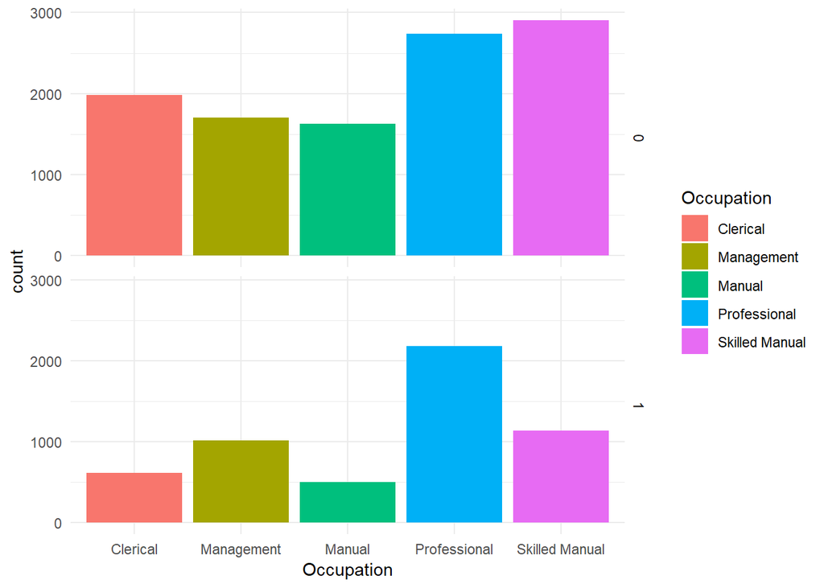

```r
ggplot(customerData, aes(Occupation, fill = Occupation)) +
  geom_bar() +
  facet_grid(rows = vars(factor(BikeBuyer))) +
  theme_minimal()
```

The most common occupation type for customers who bought a bike is NOT skilled manual.

#### Likelihood

Checking to see which gender or marital status is more *likely* to buy a bike is done by comparing total numbers of these categories that did and didn’t buy bikes.

```r
maleBuyers <- customerData %>% filter(Gender == "M", BikeBuyer == 1) %>% nrow()
males <- customerData %>% filter(Gender == "M") %>% nrow()

femaleBuyers <- customerData %>% filter(Gender == "F", BikeBuyer == 1) %>% nrow()
females <- customerData %>% filter(Gender == "F") %>% nrow()

cat("Male likelihood:   ", maleBuyers/males, "\nFemale likelihood: ", femaleBuyers/females)
```

```
## Male likelihood:    0.388661
## Female likelihood:  0.2752034
```

Male customers are more likely to buy bikes than female customers.

```r
marriedBuyers <- customerData %>% filter(MaritalStatus == "M", BikeBuyer == 1) %>% nrow()
married <- customerData %>% filter(MaritalStatus == "M") %>% nrow()

singleBuyers <- customerData %>% filter(MaritalStatus == "S", BikeBuyer == 1) %>% nrow()
singles <- customerData %>% filter(MaritalStatus == "S") %>% nrow()

cat("Married likelihood: ", marriedBuyers/married, "\nSingle likelihood:  ", singleBuyers/singles)
```

```
## Married likelihood:  0.2484184
## Single likelihood:   0.4311441
```

A maried customer is NOT more likely to buy a bike.

## Save Data

The last thing we’ll do is write a csv file containing all the feature engineering we did on the data set.

```r
write.csv(customerData, "../customerData.csv", row.names = FALSE)
```